# R Notebook

# 1 Wczytanie danych i potrzebnych pakietów

```r
library(tidyverse)
library(multcomp)
dane <- read.csv2('../data/not_comply_measures.txt')
dane <- dane %>%
  arrange(city, radar, kind, type, measurement) %>%
  mutate(kind_final = ifelse(radar, kind, 'before'))
dane
```

| city | measurement | type | kind | radar | not_comply | kind_final |
| --- | --- | --- | --- | --- | --- | --- |
| Aleksandrów | 1 | Ciężarowe | fotoradar | FALSE | 95 | before |
| Aleksandrów | 2 | Ciężarowe | fotoradar | FALSE | 76 | before |
| Aleksandrów | 3 | Ciężarowe | fotoradar | FALSE | 83 | before |
| Aleksandrów | 1 | Ciężarowe z przyczepą i autobusy | fotoradar | FALSE | 96 | before |
| Aleksandrów | 2 | Ciężarowe z przyczepą i autobusy | fotoradar | FALSE | 79 | before |
| Aleksandrów | 3 | Ciężarowe z przyczepą i autobusy | fotoradar | FALSE | 87 | before |
| Aleksandrów | 1 | Dostawcze | fotoradar | FALSE | 93 | before |
| Aleksandrów | 2 | Dostawcze | fotoradar | FALSE | 71 | before |
| Aleksandrów | 3 | Dostawcze | fotoradar | FALSE | 85 | before |
| Aleksandrów | 1 | Jednoślady | fotoradar | FALSE | 93 | before |

[output cut: 190 more lines]

# 2 Jednoczynnikowa anova i porównania parami

## 2.1 Wprowadzenie teoretyczne

ANOVA = Analysis Of Variance

Oznaczenia:

- $y$ – cecha ciągła
- $X$ – jakościowa zmienna objaśniająca (zmienna grupująca)
- $k$ – liczba poziomów, które przyjmuje cecha $X$
- $y_{ij}$ – wartość $j$-tej obserwacji w $i$-tej grupie
- $n$ – liczba obserwacji

$$y_{ij} \sim N(\mu_i, \sigma^2),$$

gdzie: $1 \leq i \leq k$, $1 \leq j \leq n_i$, $\sum_{i=1}^{k} n_i = n$, $\mu_i$ to średnia wartość zmiennej objaśnianej w grupie $i$, $\sigma^2$ wariancja, która jet równa dla wszystkich grup ($\sigma^2_1 = \sigma^2_2 = .. = \sigma^2_{k} = \sigma^2$).

Jeżeli $\forall_{k \neq l} n_k = n_l$ to mówimy o układzie zrównoważonym (ang. balanced), w przeciwnym wypadku ($\exists_{k \neq l} n_k \neq n_l$) to jest to układ niezrównoważony (ang. unbalanced).

W jednokierunkowej analizie wariancji testujemy następujący układ hipotez

$$H_0: \mu_1 = \mu_2 = ... = \mu_k,$$

przeciwko alternatywnej

$$H_1: \exists_{i \neq m} \mu_i = \mu_m$$

Można użyć również następujacej paramteryzacji

$$\begin{cases}
\mu_1 & = \mu + \alpha_1 \\
\mu_2 & = \mu + \alpha_2 \\
... \\
\mu_k & = \mu + \alpha_k \\
\end{cases}$$
gdzie $\alpha_i$ to różnica pomiędzy średnią $\mu_i$, a średnią globalną $\mu$.

Dlatego, że parametrów w takim ukłądzie jest $k+1$ ($\mu$ + $\alpha_i$), a średnich tylko $k$ wprowadza się następujące m.in. następujące ograniczenia (dwa najczęstsze):

- sumy (w R `contr.sum`)
  $$\sum_{i=1}^k \alpha_i = 0$$
  przy założeniu, że $\mu$ to średnia w populacji,
- grupy referencyjnej (w R `contr.treatment`)

$$\alpha_1 = 0$$
gdzie pierwsza grupa jest referencyjną, $\mu$ to średnia w tej grupie, a $\alpha_i$ to różnica w średnich pomiędzy $i$ tą grupą, a pierwszą / referencyjną. Uwaga, w SAS domyślny poziom referencyjny to ostatni!

Problem ten możemy również zapisać w postaci modelu liniowego

$$y = X\beta + \epsilon,$$
gdzie $\beta = (\mu, \alpha_2,...,\alpha_k)$ ponieważ w takim przypadku domyślnie zakładamy, że pierwsza grupa jest referencyjna ($\mu = \mu_1$), a $\epsilon \sim N(0, \boldsymbol{I}_{n \times n}\sigma^1)$.

## 2.2 Przykład – czy wszystkie pojazdy przestrzegają tak samo prędokości?

Wybierzemy dane przed ustawieniem automatycznego pomiaru prędkości.

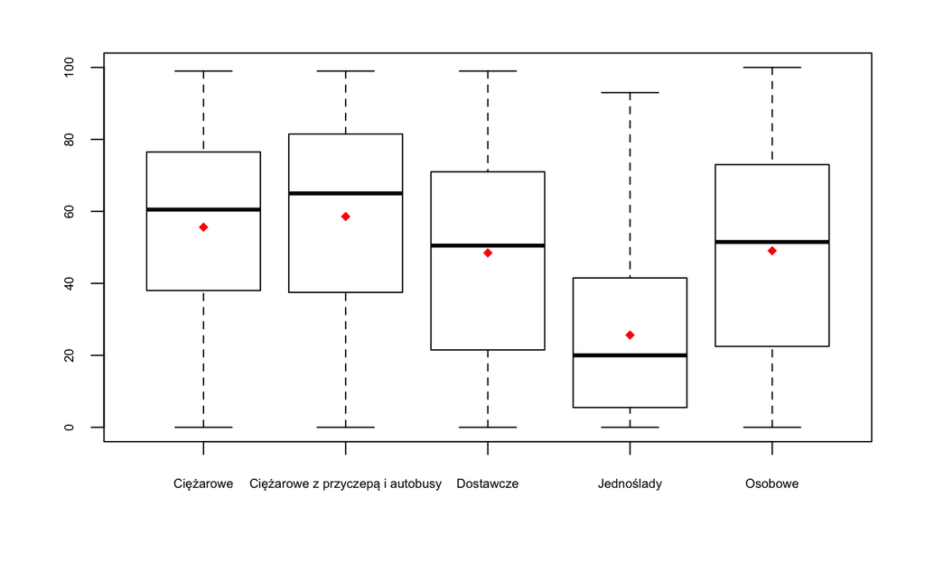

```r
dane_przed <- dane %>% filter(radar == FALSE)
boxplot(not_comply ~ type, data = dane_przed, cex.axis = 0.6)
means <- tapply(dane_przed$not_comply,dane_przed$type,mean)
points(means, col = "red", pch = 18)
```

Na wykresie widzimy zróżnicowanie w przypadku pojazdów. Najwięcej przestrzegających było w grupie jednośladów. Należy jednak podkreślić, że liczba jednośladów była mała. Dodatkowo widzimy, że założenie o stałej wariancji będzie błędne.

```r
dane_przed %>%
  group_by(type) %>%
  summarise(srednia = mean(not_comply),
            wariancja = var(not_comply))
```

| type | srednia | wariancja |
| --- | --- | --- |
| Ciężarowe | 55.60897 | 710.1880 |
| Ciężarowe z przyczepą i autobusy | 58.57051 | 821.3563 |
| Dostawcze | 48.46795 | 814.1086 |
| Jednoślady | 25.64103 | 534.8897 |
| Osobowe | 49.06410 | 845.1313 |

Przeprowadzimy jednoczynnikową anovę z wykorzystaniem funkcji `aov` oraz `lm` i `anova`

```r
anova_1 <- aov(not_comply ~ type, dane_przed)
anova_1
```

```
Call:
   aov(formula = not_comply ~ type, data = dane_przed)

Terms:
                    type Residuals
Sum of Squares  104442.9  577479.5
Deg. of Freedom        4       775

Residual standard error: 27.29716
Estimated effects may be unbalanced
```

```r
summary(anova_1)
```

```
             Df Sum Sq Mean Sq F value Pr(>F)
type          4 104443   26111   35.04 <2e-16 ***
Residuals   775 577479     745
---
Signif. codes:  0 ‘***’ 0.001 ‘**’ 0.01 ‘*’ 0.05 ‘.’ 0.1 ‘ ’ 1
```

```r
lm_1 <- lm(not_comply ~ type, dane_przed)
anova(lm_1)
```

```
Analysis of Variance Table

Response: not_comply
           Df Sum Sq Mean Sq F value    Pr(>F)
type        4 104443 26110.7  35.042 < 2.2e-16 ***
Residuals 775 577479   745.1
---
Signif. codes:  0 ‘***’ 0.001 ‘**’ 0.01 ‘*’ 0.05 ‘.’ 0.1 ‘ ’ 1
```

Zobaczmy, jak kodowane są dane w przypadku regresji z funkcją `model.matrix`

```r
model.matrix(not_comply ~ type, dane_przed) %>%
  head()
```

```
  (Intercept) typeCiężarowe z przyczepą i autobusy typeDostawcze typeJednoślady typeOsobowe
1           1                                    0             0              0           0
2           1                                    0             0              0           0
3           1                                    0             0              0           0
4           1                                    1             0              0           0
5           1                                    1             0              0           0
6           1                                    1             0              0           0
```

## 2.3 Porównanie parami

Póki co Anova nie odpowada nam na pytanie, które pary się różnią, jedynie, że się różnią. Co możemy zrobić aby to poznać? Możemy skorzystać z porównania parami

```r
pairwise.t.test(dane_przed$not_comply,dane_przed$type)
```

```
    Pairwise comparisons using t tests with pooled SD

data:  dane_przed$not_comply and dane_przed$type

                                 Ciężarowe Ciężarowe z przyczepą i autobusy Dostawcze Jednoślady
Ciężarowe z przyczepą i autobusy 0.6765    -                                -         -
Dostawcze                        0.0845    0.0068                           -         -
Jednoślady                       < 2e-16   < 2e-16                          2.8e-12   -
Osobowe                          0.1036    0.0109                           0.8471    8.0e-13

P value adjustment method: holm
```

Wykorzystajmy testy porównania parami, ale najpierw sprawdźmy czy wszystkie grupy są tak samo liczne

```r
table(dane_przed$type)
```

```
                       Ciężarowe Ciężarowe z przyczepą i autobusy                        Dostawcze
                             156                              156                              156
                      Jednoślady                          Osobowe
                             156                              156
```

Jeżeli są, to możemy zastosować porównanie parami dla grup o takiej samej wielkości, m.in:

- test HSD Tukeya
- test Studenta-Newmana-Keulsa
- test LSD Fishera czy test Scheffe – choć nie zakłada tej samej liczebności

```r
TukeyHSD(anova_1) ## pakiet stats
```

```
  Tukey multiple comparisons of means
    95% family-wise confidence level

Fit: aov(formula = not_comply ~ type, data = dane_przed)

$type
                                                   diff        lwr        upr     p adj
Ciężarowe z przyczepą i autobusy-Ciężarowe    2.9615385  -5.489343  11.412420 0.8736738
Dostawcze-Ciężarowe                          -7.1410256 -15.591908   1.309856 0.1425949
Jednoślady-Ciężarowe                        -29.9679487 -38.418831 -21.517067 0.0000000
Osobowe-Ciężarowe                            -6.5448718 -14.995754   1.906010 0.2135651
Dostawcze-Ciężarowe z przyczepą i autobusy  -10.1025641 -18.553446  -1.651682 0.0099172
Jednoślady-Ciężarowe z przyczepą i autobusy -32.9294872 -41.380369 -24.478605 0.0000000
Osobowe-Ciężarowe z przyczepą i autobusy     -9.5064103 -17.957292  -1.055528 0.0184453
Jednoślady-Dostawcze                        -22.8269231 -31.277805 -14.376041 0.0000000
Osobowe-Dostawcze                             0.5961538  -7.854728   9.047036 0.9996910
Osobowe-Jednoślady                           23.4230769  14.972195  31.873959 0.0000000
```

Teraz spójrzmy na testy z pakietu `agricolae`

```r
HSD.test(anova_1,'type', console = T)
```

```
Study: anova_1 ~ "type"

HSD Test for not_comply

Mean Square Error:  745.1348

type,  means

                                 not_comply      std   r Min Max
Ciężarowe                          55.60897 26.64935 156   0  99
Ciężarowe z przyczepą i autobusy   58.57051 28.65931 156   0  99
Dostawcze                          48.46795 28.53259 156   0  99
Jednoślady                         25.64103 23.12768 156   0  93
Osobowe                            49.06410 29.07114 156   0 100

alpha: 0.05 ; Df Error: 775
Critical Value of Studentized Range: 3.866757

Honestly Significant Difference: 8.450882

Means with the same letter are not significantly different.

Groups, Treatments and means
a    Ciężarowe z przyczepą i autobusy    58.57
ab   Ciężarowe                           55.61
b    Osobowe                             49.06
b    Dostawcze                           48.47
c    Jednoślady                          25.64
```

```r
SNK.test(anova_1,'type', console = T)
```

```
Study: anova_1 ~ "type"

Student Newman Keuls Test
for not_comply

Mean Square Error:  745.1348

type,  means

                                 not_comply      std   r Min Max
Ciężarowe                          55.60897 26.64935 156   0  99
Ciężarowe z przyczepą i autobusy   58.57051 28.65931 156   0  99
Dostawcze                          48.46795 28.53259 156   0  99
Jednoślady                         25.64103 23.12768 156   0  93
Osobowe                            49.06410 29.07114 156   0 100

alpha: 0.05 ; Df Error: 775

Critical Range
       2        3        4        5
6.067321 7.257866 7.957601 8.450882

Means with the same letter are not significantly different.

Groups, Treatments and means
a    Ciężarowe z przyczepą i autobusy    58.57
a    Ciężarowe                           55.61
b    Osobowe                             49.06
b    Dostawcze                           48.47
c    Jednoślady                          25.64
```

```r
LSD.test(anova_1,'type', console = T, p.adj  = 'holm')
```

```
Study: anova_1 ~ "type"

LSD t Test for not_comply
P value adjustment method: holm

Mean Square Error:  745.1348

type,  means and individual ( 95 %) CI

                                 not_comply      std   r      LCL      UCL Min Max
Ciężarowe                          55.60897 26.64935 156 51.31873 59.89922   0  99
Ciężarowe z przyczepą i autobusy   58.57051 28.65931 156 54.28027 62.86076   0  99
Dostawcze                          48.46795 28.53259 156 44.17770 52.75819   0  99
Jednoślady                         25.64103 23.12768 156 21.35078 29.93127   0  93
Osobowe                            49.06410 29.07114 156 44.77386 53.35435   0 100

alpha: 0.05 ; Df Error: 775
Critical Value of t: 2.815095

t-Student: 2.815095
Alpha    : 0.05
Means with the same letter are not significantly different


Groups, Treatments and means
a    Ciężarowe z przyczepą i autobusy    58.57051
ab   Ciężarowe   55.60897
b    Osobowe     49.0641
b    Dostawcze   48.46795
c    Jednoślady      25.64103
```

## 2.4 Homogeniczność wariancji

Aby sprawdzić czy wariancje są równe w grupach można skorzystać z następujących testów:

- jeżeli zmienna ma rozkład normalny:
  - test Bartletta – `bartlett.test()` – bardzo wrażliwy na złamanie tego założenia
  - test F – `var.test()` – porównanie tylko dwóch grup!!
- jeżeli zmienna nie ma rozkładnu normalnego:
  - test Flingera-Killeena – `flinger.test()`
  - test Levene’a oraz test Browna Forsytha – `levene.test()` – bardziej odporne na odstępstwa od rozkładu normalnego

```r
bartlett.test(not_comply ~ type, dane_przed)
```

```
    Bartlett test of homogeneity of variances

data:  not_comply by type
Bartlett's K-squared = 10.465, df = 4, p-value = 0.03328
```

```r
fligner.test(not_comply ~ factor(type), data = dane_przed)
```

```
    Fligner-Killeen test of homogeneity of variances

data:  not_comply by factor(type)
Fligner-Killeen:med chi-squared = 15.655, df = 4, p-value = 0.003519
```

```r
car::leveneTest(not_comply ~ factor(type), data = dane_przed)
```

```
Levene's Test for Homogeneity of Variance (center = median)
       Df F value  Pr(>F)
group   4  4.6602 0.00101 **
      775
---
Signif. codes:  0 ‘***’ 0.001 ‘**’ 0.01 ‘*’ 0.05 ‘.’ 0.1 ‘ ’ 1
```

```r
mean(dane_przed$not_comply)
```

```
[1] 47.47051
```

```r
m1 <- lm(not_comply ~ type,  data = dane_przed, contrasts = list(type = contr.sum))
summary(m1)
```

```
Call:
lm(formula = not_comply ~ type, data = dane_przed, contrasts = list(type = contr.sum))

Residuals:
    Min      1Q  Median      3Q     Max
-58.571 -21.747   2.391  21.426  67.359

Coefficients:
            Estimate Std. Error t value Pr(>|t|)
(Intercept)  47.4705     0.9774  48.568  < 2e-16 ***
type1         8.1385     1.9548   4.163 3.49e-05 ***
type2        11.1000     1.9548   5.678 1.92e-08 ***
type3         0.9974     1.9548   0.510     0.61
type4       -21.8295     1.9548 -11.167  < 2e-16 ***
---
Signif. codes:  0 ‘***’ 0.001 ‘**’ 0.01 ‘*’ 0.05 ‘.’ 0.1 ‘ ’ 1

Residual standard error: 27.3 on 775 degrees of freedom
Multiple R-squared:  0.1532,    Adjusted R-squared:  0.1488
F-statistic: 35.04 on 4 and 775 DF,  p-value: < 2.2e-16
```